# Life satisfaction in Europe

Author

Bjørn-Atle Reme

## Background

This document presents an analysis of data from the **European Social Survey (ESS)**, with a focus on **self-reported life satisfaction** across European countries.

The aim is twofold:

1. To show how to move from a raw survey file to a clean and well-labelled analysis dataset using the tidyverse.
2. To explore patterns in life satisfaction by key sociodemographic characteristics (such as age and gender) and across countries, using descriptive statistics, visualisations, and simple regression models.

Throughout, the emphasis is on a **reproducible workflow** that makes each step transparent and easy to adapt.

Before you start, please download the ESS data file in `.csv` format and place it in a folder that you can access from R. Make sure:

- Your R working directory points to the folder containing the data file.
- The path used in the code below matches where you actually saved the data.

### Load libraries and data set

In this first step, we load the packages we need and import the ESS data.  
The code below sets up the workspace: it loads the tidyverse for data handling and plotting, and reads the survey data into a single data frame, `df`.

```r
# Check and install packages if needed
packages_needed <- c("tidyverse", "gt", "relaimpo", "broom")

for (pkg in packages_needed) {
  if (!require(pkg, character.only = TRUE)) {
    install.packages(pkg)
    library(pkg, character.only = TRUE)
  }
}

# Read data file
df <- read_csv("ESS11/ESS11.csv")
```

## Inspecting the data structure

Before doing any modelling, it is helpful to get a sense of what the dataset looks like: how many observations it contains, which variables are available, and how missing values are distributed.

### Overview of the dataset

The chunk below shows the first 20 rows of the data in a nicely formatted table. This gives a quick visual impression of variable names, coding, and missingness.

```r
df %>%
  head(20) %>% #first 20 rows
  gt() %>% #apply the gt-function from the gt package to create table
  tab_style(
    style = cell_text(weight = "bold"),
    locations = cells_column_labels()
  ) %>%
  opt_table_font(font = "Roboto") %>%
  tab_options(table.font.size = "small")
```

| name | essround | edition | proddate | idno | cntry | dweight | pspwght | pweight | anweight | nwspol | netusoft | netustm | ppltrst | pplfair | pplhlp | polintr | psppsgva | actrolga | psppipla | cptppola | trstprl | trstlgl | trstplc | trstplt | trstprt | trstep | trstun | vote | prtvtdat | … |
| --- | --- | --- | --- | --- | --- | --- | --- | --- | --- | --- | --- | --- | --- | --- | --- | --- | --- | --- | --- | --- | --- | --- | --- | --- | --- | --- | --- | --- | --- | --- |
| ESS11e03 | 11 | 3 | 02.06.2025 | 50014 | AT | 1.1851145 | 0.3928906 | 0.3309145 | 0.13001321 | 90 | 5 | 180 | 5 | 5 | 5 | 1 | 4 | 5 | 4 | 5 | 6 | 9 | 10 | 5 | 5 | 5 | 5 | 1 | 1 | … |
| ESS11e03 | 11 | 3 | 02.06.2025 | 50030 | AT | 0.6098981 | 0.3251533 | 0.3309145 | 0.10759795 | 90 | 5 | 570 | 10 | 0 | 1 | 2 | 3 | 2 | 3 | 2 | 6 | 6 | 4 | 1 | 0 | 5 | 5 | 1 | 5 | … |
| ESS11e03 | 11 | 3 | 02.06.2025 | 50057 | AT | 1.3923296 | 4.0000234 | 0.3309145 | 1.32366590 | 30 | 5 | 30 | 6 | 9 | 8 | 2 | 4 | 4 | 4 | 3 | 7 | 5 | 8 | 4 | 4 | 7 | 5 | 1 | 5 | … |
| ESS11e03 | 11 | 3 | 02.06.2025 | 50106 | AT | 0.5560615 | 0.1762276 | 0.3309145 | 0.05831629 | 15 | 1 | 6666 | 6 | 6 | 6 | 3 | 2 | 2 | 2 | 3 | 5 | 6 | 9 | 3 | 3 | 4 | 4 | 2 | 66 | … |
| ESS11e03 | 11 | 3 | 02.06.2025 | 50145 | AT | 0.7227953 | 1.0609399 | 0.3309145 | 0.35108042 | 60 | 5 | 120 | 6 | 3 | 8 | 2 | 3 | 1 | 4 | 3 | 6 | 8 | 8 | 5 | 5 | 6 | 8 | 1 | 5 | … |
| ESS11e03 | 11 | 3 | 02.06.2025 | 50158 | AT | 0.9926053 | 1.3928125 | 0.3309145 | 0.46090190 | 120 | 5 | 120 | 8 | 8 | 4 | 2 | 2 | 3 | 2 | 3 | 3 | 5 | 7 | 5 | 5 | 4 | 6 | 1 | 7 | … |
| ESS11e03 | 11 | 3 | 02.06.2025 | 50211 | AT | 0.5403178 | 0.5771863 | 0.3309145 | 0.19099933 | 45 | 1 | 6666 | 7 | 7 | 8 | 2 | 2 | 2 | 2 | 2 | 6 | 5 | 8 | 4 | 5 | 4 | 6 | 1 | 1 | … |
| ESS11e03 | 11 | 3 | 02.06.2025 | 50212 | AT | 0.8146223 | 0.6194855 | 0.3309145 | 0.20499675 | 120 | 5 | 240 | 8 | 8 | 8 | 1 | 4 | 4 | 4 | 5 | 9 | 9 | 9 | 7 | 6 | 7 | 7 | 1 | 5 | … |
| ESS11e03 | 11 | 3 | 02.06.2025 | 50213 | AT | 1.3649563 | 0.6936349 | 0.3309145 | 0.22953385 | 20 | 5 | 180 | 7 | 8 | 7 | 3 | 2 | 2 | 2 | 2 | 6 | 7 | 8 | 3 | 2 | 5 | 6 | 1 | 5 | … |
| ESS11e03 | 11 | 3 | 02.06.2025 | 50235 | AT | 0.8729490 | 0.4922672 | 0.3309145 | 0.16289838 | 120 | 1 | 6666 | 3 | 4 | 3 | 2 | 3 | 2 | 3 | 3 | 8 | 8 | 10 | 8 | 8 | 4 | 8 | 1 | 2 | … |
| ESS11e03 | 11 | 3 | 02.06.2025 | 50236 | AT | 0.6989865 | 0.3552068 | 0.3309145 | 0.11754309 | 60 | 5 | 120 | 5 | 5 | 6 | 1 | 2 | 4 | 3 | 4 | 6 | 8 | 8 | 6 | 6 | 6 | 8 | 1 | 1 | … |
| ESS11e03 | 11 | 3 | 02.06.2025 | 50238 | AT | 0.8320375 | 0.3139301 | 0.3309145 | 0.10388404 | 5 | 5 | 60 | 5 | 7 | 7 | 2 | 2 | 2 | 2 | 3 | 6 | 9 | 9 | 3 | 3 | 8 | 7 | 2 | 66 | … |
| ESS11e03 | 11 | 3 | 02.06.2025 | 50240 | AT | 0.8734539 | 0.2768161 | 0.3309145 | 0.09160248 | 60 | 5 | 120 | 6 | 7 | 6 | 3 | 3 | 5 | 3 | 5 | 6 | 4 | 4 | 9 | 9 | 8 | 8 | 1 | 77 | … |
| ESS11e03 | 11 | 3 | 02.06.2025 | 50248 | AT | 0.9025512 | 0.5089600 | 0.3309145 | 0.16842224 | 90 | 1 | 6666 | 3 | 5 | 5 | 2 | 3 | 2 | 3 | 3 | 3 | 5 | 7 | 0 | 0 | 2 | 4 | 2 | 66 | … |
| ESS11e03 | 11 | 3 | 02.06.2025 | 50270 | AT | 0.5818180 | 4.0006237 | 0.3309145 | 1.32386450 | 60 | 2 | 6666 | 8 | 8 | 9 | 3 | 4 | 3 | 4 | 3 | 7 | 9 | 9 | 8 | 7 | 5 | 7 | 1 | 5 | … |
| ESS11e03 | 11 | 3 | 02.06.2025 | 50281 | AT | 0.6935217 | 0.4163573 | 0.3309145 | 0.13777868 | 180 | 5 | 180 | 3 | 8 | 9 | 1 | 2 | 3 | 2 | 3 | 2 | 6 | 7 | 2 | 2 | 3 | 3 | 1 | 1 | … |
| ESS11e03 | 11 | 3 | 02.06.2025 | 50310 | AT | 2.3245115 | 0.8770443 | 0.3309145 | 0.29022670 | 20 | 5 | 360 | 8 | 8 | 8 | 1 | 2 | 4 | 3 | 1 | 7 | 9 | 9 | 6 | 6 | 4 | 4 | 1 | 1 | … |
| ESS11e03 | 11 | 3 | 02.06.2025 | 50311 | AT | 0.9926053 | 1.3928125 | 0.3309145 | 0.46090190 | 45 | 3 | 6666 | 4 | 5 | 5 | 2 | 2 | 2 | 3 | 2 | 2 | 4 | 5 | 5 | 5 | 4 | 4 | 1 | 2 | … |
| ESS11e03 | 11 | 3 | 02.06.2025 | 50324 | AT | 1.0702981 | 1.6595315 | 0.3309145 | 0.54916310 | 5 | 5 | 600 | 2 | 2 | 2 | 4 | 3 | 1 | 3 | 3 | 4 | 5 | 6 | 1 | 1 | 5 | 5 | 1 | 1 | … |
| ESS11e03 | 11 | 3 | 02.06.2025 | 50339 | AT | 0.5560615 | 1.2854693 | 0.3309145 | 0.42538047 | 30 | 4 | 180 | 4 | 5 | 6 | 2 | 2 | 2 | 2 | 3 | 5 | 7 | 5 | 3 | 3 | 88 | 6 | 3 | 66 | … |

**Comment:** There is a lot of missing here, and not so easy to understand the variables. Do important to take a look at the codebook, which is in the folder from the data download.

## Recoding key variables

To make the results easier to read and interpret, we create labelled versions of important variables. Here we map the two-letter country codes in `cntry` to full country names, and we may also recode gender and life satisfaction into clearer forms.

```r
unique(df$cntry)
```

We then get this code:

```r
df <- df %>%
  mutate(country = recode(cntry,
    "AT" = "Austria",
    "BE" = "Belgium",
    "BG" = "Bulgaria",
    "CH" = "Switzerland",
    "CY" = "Cyprus",
    "DE" = "Germany",
    "ES" = "Spain",
    "FI" = "Finland",
    "FR" = "France",
    "GB" = "UK",
    "GR" = "Greece",
    "HR" = "Croatia",
    "HU" = "Hungary",
    "IE" = "Ireland",
    "IL" = "Israel",
    "IS" = "Iceland",
    "IT" = "Italy",
    "LT" = "Lithuania",
    "LV" = "Latvia",
    "ME" = "Montenegro",
    "NL" = "Netherlands",
    "NO" = "Norway",
    "PL" = "Poland",
    "PT" = "Portugal",
    "RS" = "Serbia",
    "SE" = "Sweden",
    "SI" = "Slovenia",
    "SK" = "Slovakia"
  ))
```

We look at data - what is the age distribution in the sample for the different countries?

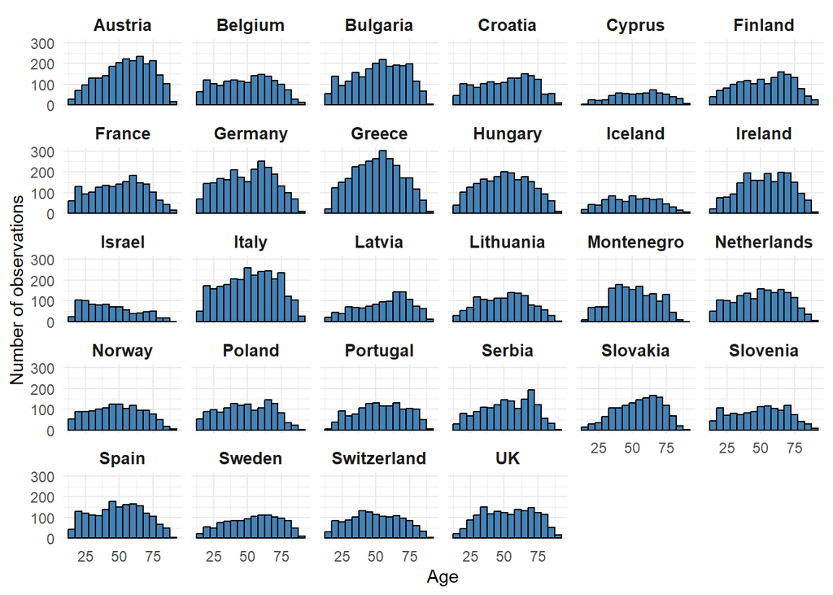

```r
df %>%
  filter(agea < 90) %>% #filter to avoid incluing missing == 999
  ggplot(aes(x = agea)) +
  geom_histogram(binwidth = 5, fill = "steelblue", color = "black") +
  facet_wrap(~country) +
  ylab("Number of observations")+
  xlab("Age")+
  theme_minimal() +
  theme(
  strip.text = element_text(face = "bold", size = 10)
)
```

## Life satisfaction by groups

We now turn to one of the central questions: **How does life satisfaction vary across age groups?**

In this section we:

1. Restrict the sample to valid responses on gender and life satisfaction.
2. Group respondents into groups.
3. Compute average life satisfaction within each group.
4. Visualise the results.

### Plot: average life satisfaction across countries

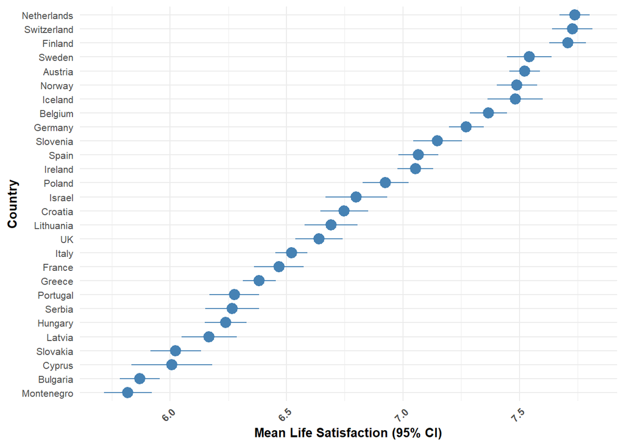

```r
df %>%
  filter(stflife %in% c(0:9)) %>% # remove values that are not valid
  group_by(country) %>%
  summarise(stf_mean = mean(stflife, na.rm = T),
            stf_sd = sd(stflife, na.rm = T),  # Fixed: was mean(), should be sd()
            stf_se = stf_sd/sqrt(n()),
            n = n()) %>%
  ggplot(aes(x = reorder(country, stf_mean), y = stf_mean)) +  # Added y mapping
  geom_pointrange(aes(ymin = stf_mean - 1.96*stf_se,
                      ymax = stf_mean + 1.96*stf_se),
                  color = "steelblue", size = 0.8) +
  labs(
    x = "Country",
    y = "Mean Life Satisfaction (95% CI)"
  ) +
  coord_flip() +
  theme_minimal() +
  theme(
    axis.text.x = element_text(angle = 45, hjust = 1, face = "bold"),
    axis.title = element_text(face = "bold"),
    text = element_text(family = "Arial", size = 10)
  )
```

### Life satisfaction by age group and gender

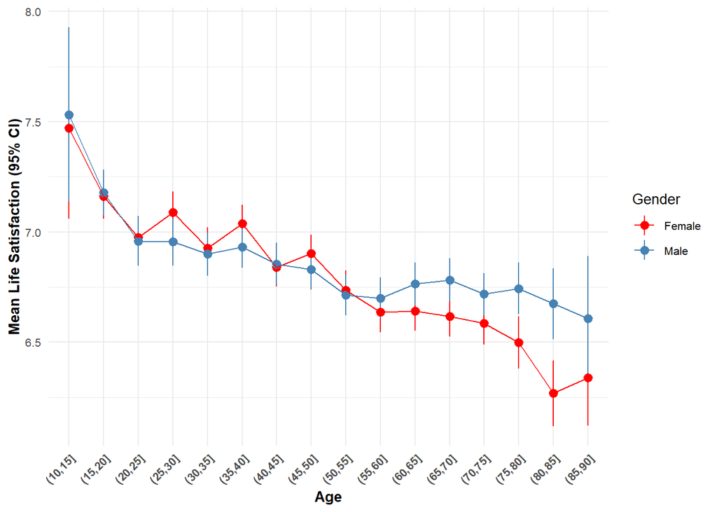

```r
df %>%
  filter(gndr < 3) %>% #include only valid response
  filter(stflife %in% c(0:9)) %>% #include only valid response
  filter(agea < 90) %>% # remove values that are not valid
  mutate(age_group = cut(agea, seq(0,100,5))) %>%
  mutate(gender = recode(gndr, `1` = "Male", `2` = "Female")) %>%
  group_by(age_group, gender) %>%
  summarise(stf_mean = mean(stflife, na.rm = T),
            stf_sd = sd(stflife, na.rm = T),
            stf_se = stf_sd/sqrt(n()),
            n = n()) %>%
  ggplot(aes(x = age_group, y = stf_mean, color = gender)) +
  geom_pointrange(aes(ymin = stf_mean - 1.96*stf_se,
                      ymax = stf_mean + 1.96*stf_se),
                  size = 0.5) +
  geom_line(aes(group = gender)) +
  scale_color_manual(values = c("Male" = "steelblue", "Female" = "red")) +
  labs(
    x = "Age",
    y = "Mean Life Satisfaction (95% CI)",
    color = "Gender"
  ) +
  theme_minimal() +
  theme(
    axis.text.x = element_text(angle = 45, hjust = 1, face = "bold"),
    axis.title = element_text(face = "bold"),
    text = element_text(family = "Arial", size = 10)
  )
```

Now, let’s explore how these relationships vary across different regions of Europe. We therefore recode to four regions to keep sufficient statistical power.

```r
region_map <- tibble(
  country = c("Iceland", "Ireland", "United Kingdom", "Norway", "Sweden", "Finland",
              "Austria", "Belgium", "Germany", "France", "Netherlands", "Switzerland",
              "Spain", "Portugal", "Italy", "Greece", "Cyprus",
              "Poland", "Bulgaria", "Hungary", "Slovakia", "Slovenia", "Croatia",
              "Lithuania", "Latvia", "Serbia", "Montenegro", "Israel"),
  region = c(rep("Northern", 6),
             rep("Western", 6),
             rep("Southern", 5),
             rep("Eastern", 10),
             "Other")
)

df <- df %>%
  left_join(region_map, by = "country")
```

### Life satisfaction by age group, gender, and region

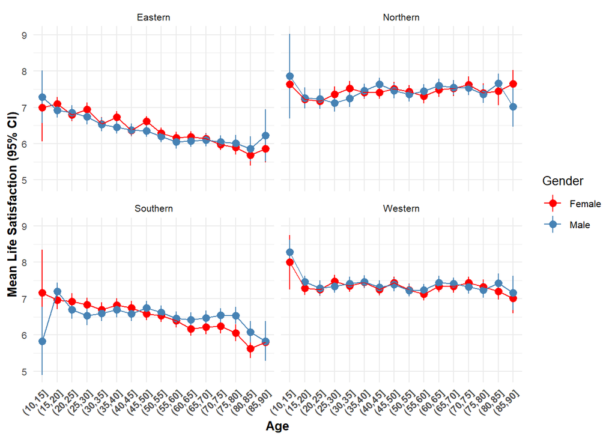

```r
df %>%
  filter(!region.y %in% c("Other")) %>%
  filter(!is.na(region.y)) %>%
  filter(gndr < 3) %>% #include only valid response
  filter(stflife %in% c(0:9)) %>% #include only valid response
  filter(agea < 90) %>% # remove values that are not valid
  mutate(age_group = cut(agea, seq(0,100,5))) %>%
  mutate(gender = recode(gndr, `1` = "Male", `2` = "Female")) %>%
  group_by(age_group, gender, region.y) %>%
  summarise(stf_mean = mean(stflife, na.rm = T),
            stf_sd = sd(stflife, na.rm = T),
            stf_se = stf_sd/sqrt(n()),
            n = n()) %>%
  ggplot(aes(x = age_group, y = stf_mean, color = gender)) +
  geom_pointrange(aes(ymin = stf_mean - 1.96*stf_se,
                      ymax = stf_mean + 1.96*stf_se),
                  size = 0.5) +
  geom_line(aes(group = gender)) +
  scale_color_manual(values = c("Male" = "steelblue", "Female" = "red")) +
  labs(
    x = "Age",
    y = "Mean Life Satisfaction (95% CI)",
    color = "Gender"
  ) +
  theme_minimal() +
  theme(
    axis.text.x = element_text(angle = 45, hjust = 1, face = "bold"),
    axis.title = element_text(face = "bold"),
    text = element_text(family = "Arial", size = 10)
  ) +
  facet_wrap(~region.y)
```

### Modelling

In this subsection we move beyond simple descriptives, but start doing some simple regression modelling. To start off with something easy we model whether there is an association between life satisfaction and health, after adjusting for income.

```r
model = df %>%
  filter(hinctnta < 11) %>%
  filter(health < 6) %>%
  mutate(health = 6-health) %>%
  filter(stflife %in% c(0:9)) %>%
  lm(stflife ~ factor(hinctnta) + factor(health), data = .)

summary(model)
```

```
Call:
lm(formula = stflife ~ factor(hinctnta) + factor(health), data = .)

Residuals:
    Min      1Q  Median      3Q     Max
-7.8472 -0.8752  0.4023  1.2590  5.1506

Coefficients:
                   Estimate Std. Error t value Pr(>|t|)
(Intercept)         3.84936    0.09158  42.031  < 2e-16 ***
factor(hinctnta)2   0.29759    0.05047   5.896 3.75e-09 ***
factor(hinctnta)3   0.39889    0.04923   8.103 5.57e-16 ***
factor(hinctnta)4   0.53314    0.04899  10.882  < 2e-16 ***
factor(hinctnta)5   0.63277    0.04929  12.838  < 2e-16 ***
factor(hinctnta)6   0.77589    0.04901  15.830  < 2e-16 ***
factor(hinctnta)7   0.81356    0.04889  16.640  < 2e-16 ***
factor(hinctnta)8   0.99246    0.04968  19.976  < 2e-16 ***
factor(hinctnta)9   1.14398    0.05239  21.837  < 2e-16 ***
factor(hinctnta)10  1.25562    0.05296  23.711  < 2e-16 ***
factor(health)2     1.09991    0.09458  11.630  < 2e-16 ***
factor(health)3     1.98816    0.08900  22.339  < 2e-16 ***
factor(health)4     2.49275    0.08857  28.145  < 2e-16 ***
factor(health)5     2.74219    0.08991  30.500  < 2e-16 ***
---
Signif. codes:  0 '***' 0.001 '**' 0.01 '*' 0.05 '.' 0.1 ' ' 1

Residual standard error: 1.789 on 32531 degrees of freedom
Multiple R-squared:  0.1259,    Adjusted R-squared:  0.1256
F-statistic: 360.5 on 13 and 32531 DF,  p-value: < 2.2e-16
```

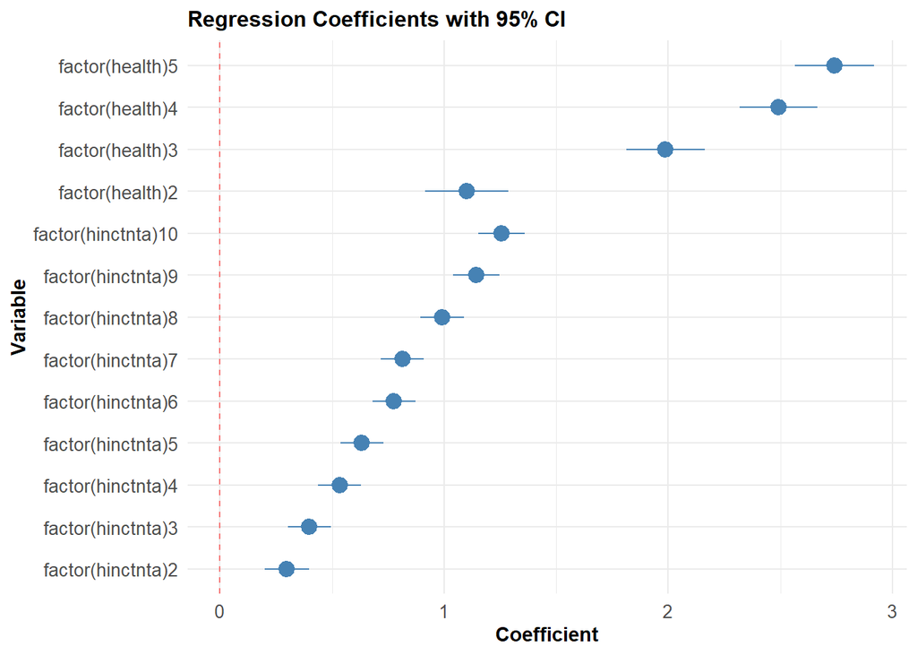

```r
# Pointrange plot of coefficients
model %>%
  tidy(conf.int = TRUE) %>%
  filter(term != "(Intercept)") %>%
  mutate(
    var_type = ifelse(str_detect(term, "hinctnta"), "Income", "Health"),
    var_level = as.numeric(str_extract(term, "\\d+"))
  ) %>%
  mutate(sort_order = ifelse(var_type == "Income", var_level, 100 + var_level)) %>%
  mutate(term = fct_reorder(term, sort_order)) %>%
  ggplot(aes(x = term, y = estimate)) +
  geom_pointrange(aes(ymin = conf.low, ymax = conf.high),
                  color = "steelblue", size = 0.8) +
  geom_hline(yintercept = 0, linetype = "dashed", color = "red", alpha = 0.5) +
  coord_flip() +
  labs(
    title = "Regression Coefficients with 95% CI",
    x = "Variable",
    y = "Coefficient"
  ) +
  theme_minimal() +
  theme(
    axis.title = element_text(face = "bold", size = 11),
    plot.title = element_text(face = "bold", size = 12),
    axis.text = element_text(size = 10)
  )
```

### Modelling: comparing the role of income, health, and socialization

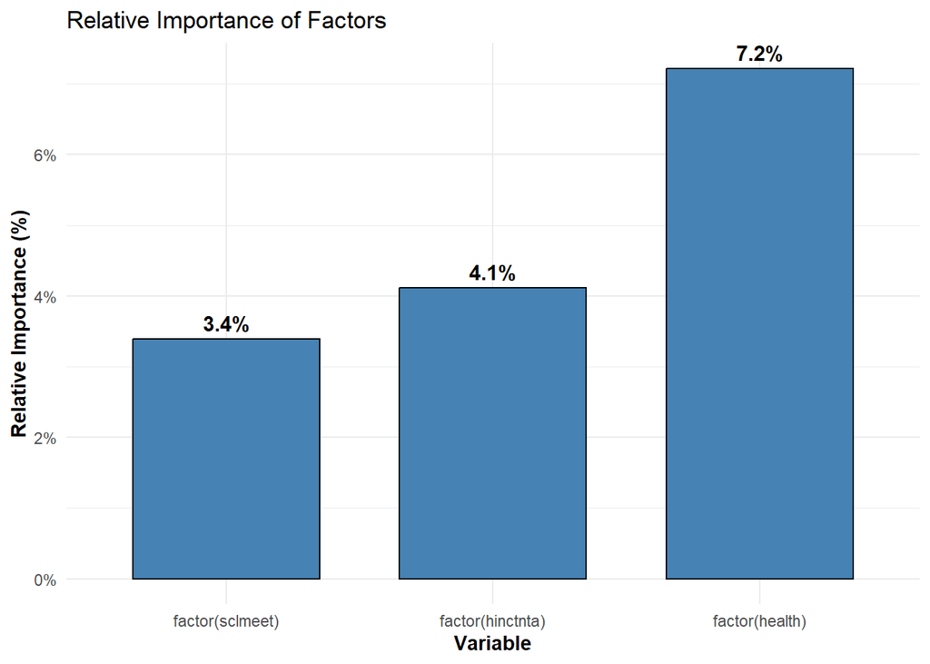

```r
model = df %>%
  filter(sclmeet < 8) %>%
  filter(hinctnta < 11) %>%
  filter(health < 6) %>%
  filter(stflife %in% c(0:9)) %>%
  lm(stflife ~ factor(sclmeet) + factor(hinctnta) + factor(health), data = .)

relimpo_results <- calc.relimp(model, type = "lmg")

# Or create a nice plot
results = relimpo_results$lmg %>%
  as.data.frame()

colnames(results) = c("value")

results %>%
  rownames_to_column("variable") %>%
  ggplot(aes(x = reorder(variable, value), y = value)) +
  geom_col(fill = "steelblue", color = "Black", width = 0.7) +
  geom_text(aes(label = paste0(round(value, 3)*100, "%")),
            vjust = -0.5, size = 4, fontface = "bold") +
  scale_y_continuous(labels = scales::percent) +
  labs(
    title = "Relative Importance of Factors",
    x = "Variable",
    y = "Relative Importance (%)"
  ) +
  theme_minimal() +
  theme(
    axis.title = element_text(face = "bold"),
    text = element_text(size = 11)
  )
```

### Modelling: relative importance of health, income and socialization by age-group

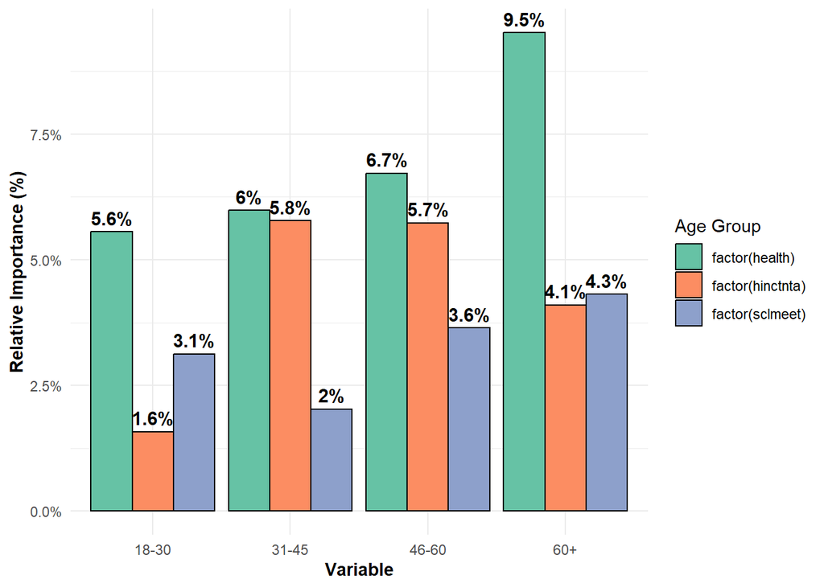

```r
results <- df %>%
  filter(sclmeet < 8) %>%
  filter(hinctnta < 11) %>%
  filter(health < 6) %>%
  filter(stflife %in% c(0:9)) %>%
  filter(agea < 90) %>%
  mutate(age_group = cut(agea, breaks = c(0, 30, 45, 60, 100),
                         labels = c("18-30", "31-45", "46-60", "60+"))) %>%
  filter(!is.na(age_group)) %>%
  nest(data = -age_group) %>%
  mutate(model = map(data, ~lm(stflife ~ factor(sclmeet) + factor(hinctnta) + factor(health), data = .x))) %>%
  mutate(relimpo_df = map(model, function(m) {
    calc.relimp(m, type = "lmg")$lmg %>%
      enframe(name = "variable", value = "value")
  })) %>%
  unnest(relimpo_df)

# Check what columns exist
results <- results[, c("age_group", "variable", "value")]

results %>%
  ggplot(aes(x = reorder(age_group, value), y = value, fill = variable)) +
  geom_col(color = "Black", position = "dodge") +
  geom_text(aes(label = paste0(round(value, 3)*100, "%")), vjust = -0.5, size = 4, fontface = "bold",
            position = position_dodge(width = 0.9)) +
  scale_fill_brewer(palette = "Set2") +
  scale_y_continuous(labels = scales::percent) +
  labs(
    x = "Variable",
    y = "Relative Importance (%)",
    fill = "Age Group"
  ) +
  theme_minimal() +
  theme(
    axis.title = element_text(face = "bold"),
    text = element_text(size = 11)
  )
```